# What is the light cytosol?

Tom Smith

Cambridge Centre for Proteomics

19 September, 2023

Abstract

Here, we consider the RNAs in the ‘light cytosol’ to try and understand what this profile represents

```r
library(tidyverse)
library(camprotR)
library(pRoloc)
library(pRolocdata)
library(pRolocExt)
library(ggtern)
library(biomaRt)
library(ggbeeswarm)
```

Read in the proportions and dLoRNA quantification

```r
proportions <- readRDS('./out/proportions_single_table.rds')
proportions_per_rep <- readRDS('./out/proportions_per_rep_single_table_flt.rds')
```

```r
dlorna <- readRDS('../2_clustering/out/all_datasets_with_novel.rds')
```

Annotate the proportions with features from quantification object.

```r
proportions_annotated <- proportions %>%
  names() %>%
  lapply(function(level){
    proportion_annotated <- proportions[[level]] %>%
      rowwise() %>%
      mutate(Nuc=sum(Nucleus, Nucleolus, na.rm=TRUE)) %>%
      dplyr::select(id, condition, Cytosol, Nuc, Membrane, Cytosol_Light)

    if(level=='transcript'){
      proportion_annotated <- proportion_annotated %>%
        merge(fData(dlorna[[level]]$DMSO$corrected)[
          , c('ensembl_gene_id', 'gene_biotype', 'transcript_biotype',
              'external_gene_name', 'chromosome_name', 'transcript_length')],
        by.x='id', by.y='row.names')
    } else{
      proportion_annotated <- proportion_annotated %>%
        merge(fData(dlorna[[level]]$DMSO$corrected)[
          , c('gene_biotype', 'external_gene_name', 'chromosome_name')],
        by.x='id', by.y='row.names')

    }

    return(proportion_annotated)

  })

names(proportions_annotated) <- names(proportions)

proportions %>% lapply(dim)
```

```
$gene
[1] 27947    12

$transcript
[1] 69518    12
```

```r
proportions_annotated %>% lapply(dim)
```

```
$gene
[1] 27779     9

$transcript
[1] 68279    12
```

```r
mean_proportions_to_plot <- proportions_annotated %>%
  names() %>%
  lapply(function(level){
    if(level=='transcript'){
      biotype_col='transcript_biotype'
    } else {biotype_col='gene_biotype'}


    proportions_annotated[[level]] %>%
        filter(!!sym(biotype_col) %in% c('protein_coding', 'lncRNA',
                                         'nonsense_mediated_decay', 'processed_transcript',
                                         'retained_intron')) %>%
      mutate(biotype=!!sym(biotype_col)) %>%
      pivot_longer(cols=c(Cytosol, Cytosol_Light, Membrane, Nuc),
                   names_to='localisation',
                   values_to='proportion')
  })
names(mean_proportions_to_plot) <- names(proportions_annotated)
```

Read in the ribosome profiling data from Teemu et al (2015).

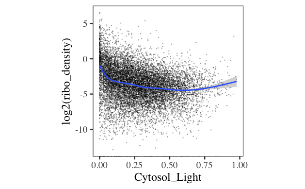

```r
ribosome_profiling <- readRDS('../../../../../1_external/2_ribosome_profiling/out/Teemu_et_al_2015_ribosome_profiling.rds') %>%
  dplyr::select(ribo_density)

to_plot <- proportions_annotated$gene %>%
  filter(condition=='DMSO') %>%
  dplyr::select(id, Cytosol_Light) %>%
  merge(ribosome_profiling, by.x='id', by.y='row.names')

to_plot %>%
  ggplot(aes(Cytosol_Light, log2(ribo_density))) +
  geom_point(size=0.25, alpha=0.25) +
  theme_camprot() +
  geom_smooth()
```

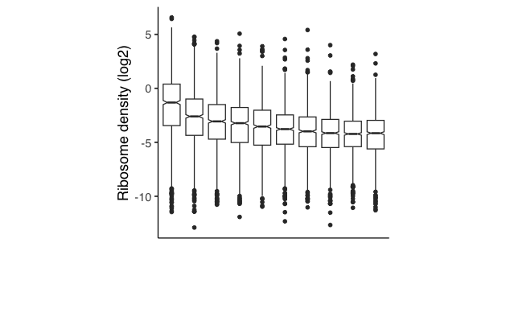

```r
p <- to_plot %>%
  ggplot(aes(Hmisc::cut2(Cytosol_Light, g=10),
             log2(ribo_density))) +
  geom_boxplot(notch=TRUE) +
  theme_camprot(border=FALSE, base_family='sans', base_size=15) +
  ylab('Ribosome density (log2)') +
  xlab('\n\n\n') +
  theme(axis.text.x=element_blank(), axis.ticks.x=element_blank())

print(p)
```

```r
range <- log2(to_plot$ribo_density)
range <- range[is.finite(range)]

range_range <- max(range)-min(range)
tri_min <- max(range) - (range_range*1.15)
tri_max <- max(range) - (range_range*1.1)

p2 <- p +
  annotate(geom='polygon', x=c(1,10,10,1), y=c(tri_min, tri_min, tri_max, tri_min), fill='grey40')  +
  annotate(geom='text', x=5.5, y=(max(range) - (range_range*1.2)), label='Cytosol light proportion', size=5, vjust=0.5) +
  coord_cartesian(ylim=c(min(range), max(range)), clip = 'off')

print(p2)

ggsave('../../../../../5_manuscript_figures/Figure_5/ribo_density_length/Ribosome_density.png', p2, width=3.5, height=3.5)
```

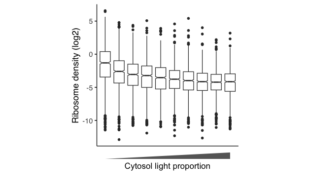

```r
ggsave('../../../../../5_manuscript_figures/Figure_5/ribo_density_length/Ribosome_density.pdf', p2, width=3.5, height=3.5)
```

OK, so there’s a clear relationship between cytosol light proportion and the ribsome density, with ~8-fold difference between the bottom and top 10% by cytosol light proportion.

Let’s also look at the relationship between transcript length and cytosol light proportion.

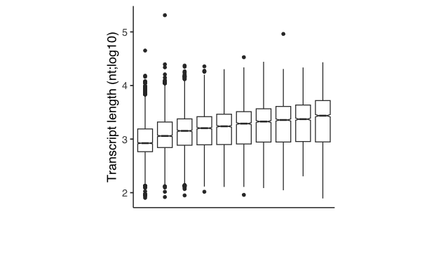

```r
p <- proportions_annotated$transcript %>%
  filter(condition=='DMSO') %>%
  ggplot(aes(Hmisc::cut2(Cytosol_Light, g=10),
             log10(transcript_length))) +
  geom_boxplot(notch=TRUE) +
  theme_camprot(border=FALSE, base_family='sans', base_size=15) +
  ylab('Transcript length (nt;log10)') +
  xlab('\n\n\n') +
  theme(axis.text.x=element_blank(), axis.ticks.x=element_blank())

print(p)
```

```r
range <- proportions_annotated$transcript %>%
  filter(condition=='DMSO') %>%
  pull(transcript_length) %>%
  log10()
range <- range[is.finite(range)]

range_range <- max(range)-min(range)
tri_min <- max(range) - (range_range*1.15)
tri_max <- max(range) - (range_range*1.1)

p2 <- p +
  annotate(geom='polygon', x=c(1,10,10,1), y=c(tri_min, tri_min, tri_max, tri_min), fill='grey40')  +
  annotate(geom='text', x=5.5, y=(max(range) - (range_range*1.2)), label='Cytosol light proportion', size=5, vjust=0.5) +
  coord_cartesian(ylim=c(min(range), max(range)), clip = 'off')

print(p2)

ggsave('../../../../../5_manuscript_figures/Figure_5/ribo_density_length/length.png', p2, width=3.5, height=3.5)
```

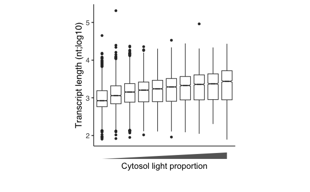

```r
ggsave('../../../../../5_manuscript_figures/Figure_5/ribo_density_length/length.pdf', p2, width=3.5, height=3.5)
```

```r
deseq_results <- readRDS('../../1_Differential_abundance/results/DESeq2_results_no_lf_compression.rds')
```

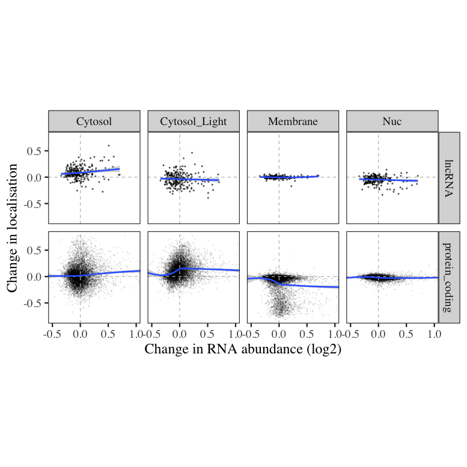

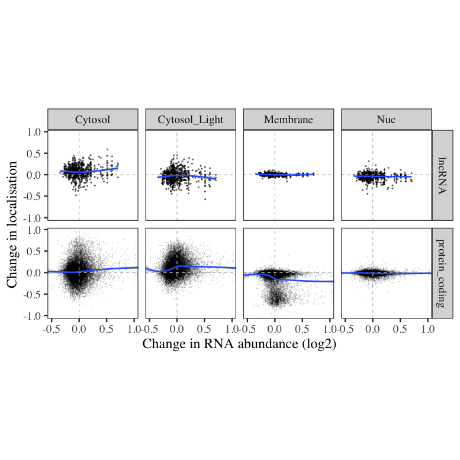

```r
to_plot_vs_exp_diff <- mean_proportions_to_plot %>%
  names() %>%
  lapply(function(level){
    x_key <- ifelse(level=='transcript', 'ensembl_gene_id', 'id')

    mean_proportions_to_plot[[level]] %>%
      #dplyr::select(id, ensembl_gene_id, biotype, condition, localisation, proportion) %>%
      pivot_wider(names_from=condition, values_from=proportion) %>%
      merge(deseq_results, by.x=x_key, by.y='row.names') %>%
      mutate(diff=Tg-DMSO)
  })

names(to_plot_vs_exp_diff) <- names(mean_proportions_to_plot)

to_plot_vs_exp_diff %>%
  names() %>%
  lapply(function(level){
    to_plot_vs_exp_diff[[level]] %>%
      filter(baseMean>2^10, biotype %in% c('lncRNA', 'protein_coding')) %>%
      ggplot(aes(log2FoldChange, diff)) +
      geom_point(aes(size=biotype, alpha=biotype)) +
      theme_camprot() +
      scale_size_manual(values=c(0.5, 0.1), guide=FALSE) +
      scale_alpha_manual(values=c(0.5, 0.1), guide=FALSE) +
      facet_grid(biotype~localisation) +
      geom_vline(xintercept=0, linetype=2, colour='grey') +
      geom_hline(yintercept=0, linetype=2, colour='grey') +
      geom_smooth() +
      coord_cartesian(xlim=c(-0.5, 1)) +
      xlab('Change in RNA abundance (log2)') +
      ylab('Change in localisation')
  })
```

OK, so it looks like those protein-coding genes/transcripts that start in the membrane and move towards the Cytosol_Light might have slight increase in abundance overall. That would be unexpected. Let’s look at that more directly

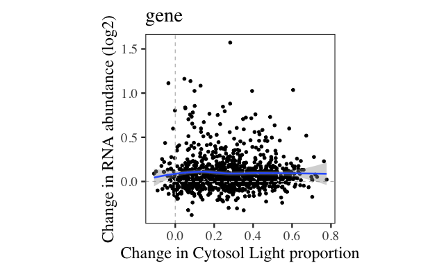

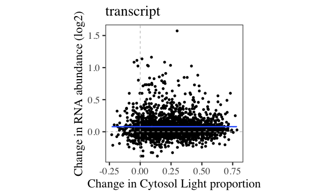

```r
mean_proportions_to_plot %>% names() %>%
  lapply(function(level){

  membrane_rnas <- mean_proportions_to_plot[[level]] %>%
    filter(biotype=='protein_coding', condition=='DMSO', localisation=='Membrane', proportion>=0.5) %>%
    pull(id)

  to_plot_vs_exp_diff[[level]] %>%
    filter(localisation=='Cytosol_Light', id %in% membrane_rnas) %>%
    filter(baseMean>2^10) %>%
    ggplot(aes(diff, log2FoldChange)) +
    geom_point() +
    theme_camprot() +
    geom_vline(xintercept=0, linetype=2, colour='grey') +
    geom_hline(yintercept=0, linetype=2, colour='grey') +
    geom_smooth() +
    ggtitle(level) +
    #coord_cartesian(ylim=c(-0.5, 1)) +
    ylab('Change in RNA abundance (log2)') +
    xlab('Change in Cytosol Light proportion')
})
```

Hmmm, so no relationship whatsoever between the amount of movement towards the cytosol light and the change in RNA abundance. So the overall higher abundance for membrane-localised RNAs is independent of the relocalisation. An interesting observation nonetheless.

```r
Hubstenberger_et_al <- readRDS('../../../../../1_external/3_granules/Hubstenberger_et_al_2017/hub_p_body_rna.rds')
Hubstenberger_et_al_enr <- Hubstenberger_et_al %>% filter(enr>3, fdr<0.01)
print(nrow(Hubstenberger_et_al_enr))
```

```
[1] 343
```

```r
colours <- readRDS('../../../../../6_shiny_app/out/shiny_colours.rds')$RNA[1:6]

obj <- dlorna$gene$DMSO$corrected
fData(obj)$markers_inc_hub <- fData(obj)$markers
fData(obj)$markers_inc_hub[
  ((getMarkers(obj, 'markers')=='unknown') &
     (rownames(obj) %in% Hubstenberger_et_al_enr$ensembl_gene_id))] <- 'Hubstenberger et al P-body'
```

```
organelleMarkers
      Cytosol Cytosol_Light      Membrane Mitochondrion     Nucleolus       Nucleus       unknown
           21            20            14            13            24            29         14374
```

```r
fData(obj)$markers_inc_hub <- factor(fData(obj)$markers_inc_hub,
                                       levels=c(getMarkerClasses(obj, 'markers'),
                                                c('Hubstenberger et al P-body', 'unknown')))


p <- mrkConsProfiles(obj, fcol='markers_inc_hub') %>%
  data.frame() %>%
  tibble::rownames_to_column('markers') %>%
  pivot_longer(cols=-markers) %>%
  mutate(markers=factor(remove_x(markers), levels=levels(fData(obj)$markers_inc_hub))) %>%
  mutate(markers=recode(markers, 'Cytosol_Light'='Granule')) %>%
  merge(pData(obj), by.x='name', by.y='sample') %>%
  ggplot(aes(fraction, value, colour=markers, group=interaction(markers, replicate))) +
  geom_line(size=1) +
  theme_camprot(border=FALSE, base_size=15, base_family='sans' ) +
  facet_wrap(~(paste0('Rep. ', replicate)), nrow=1) +
  scale_colour_manual(values=c(colours, 'black'), name='') +
  theme(strip.background=element_blank()) +
  xlab('Fraction') +
  ylab('Mean abundance\n(sum norm.)')
print(p)
ggsave('../../../../../5_manuscript_figures/Figure_5/external/Hubstenberger.png', width=9, height=3.5)
```

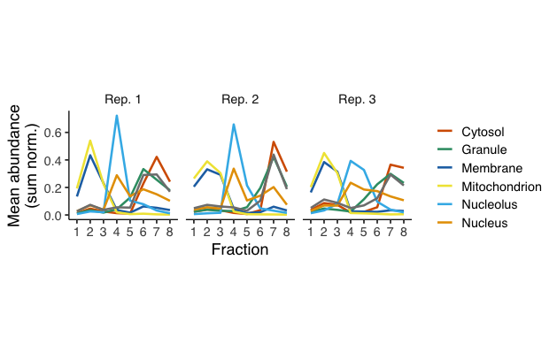

```r
ggsave('../../../../../5_manuscript_figures/Figure_5/external/Hubstenberger.pdf', width=9, height=3.5)
```

```
organelleMarkers
      Cytosol Cytosol_Light      Membrane Mitochondrion     Nucleolus       Nucleus       unknown
           21            20            14            13            24            29         14374
organelleMarkers
      Cytosol Cytosol_Light      Membrane Mitochondrion     Nucleolus       Nucleus       unknown
           21            20            14            13            24            29         14374
```

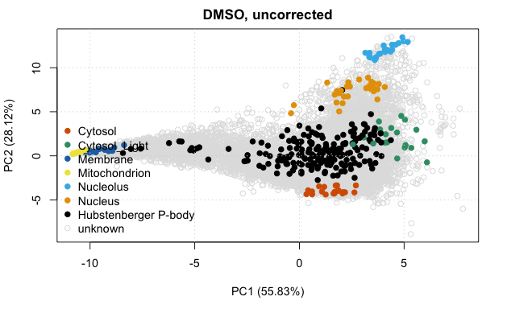

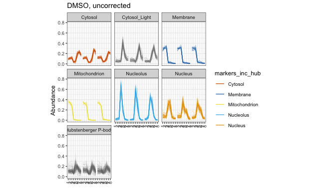

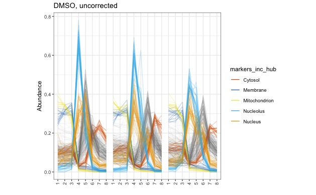

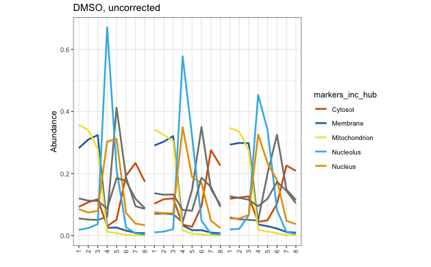

```
organelleMarkers
      Cytosol Cytosol_Light      Membrane Mitochondrion     Nucleolus       Nucleus       unknown
           21            20            14            13            24            28         14285
```

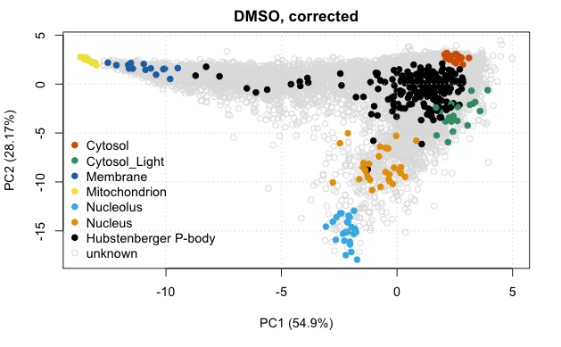

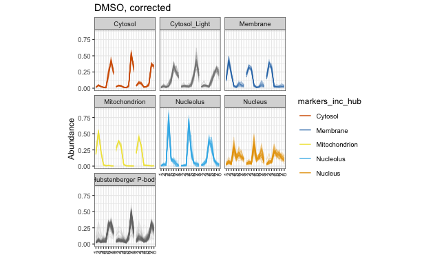

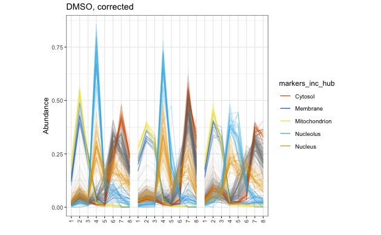

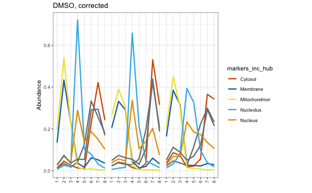

```
organelleMarkers
      Cytosol Cytosol_Light      Membrane Mitochondrion     Nucleolus       Nucleus       unknown
           21            20            14            13            24            28         14285
```

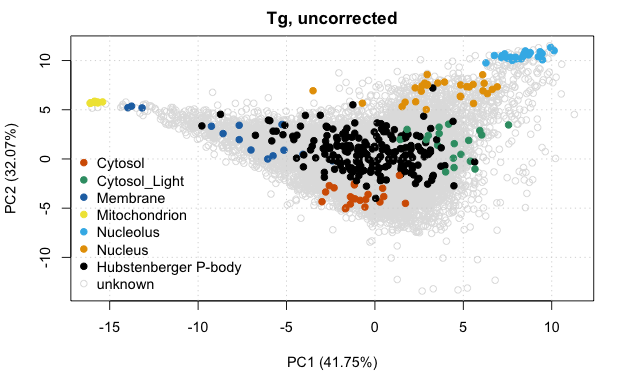

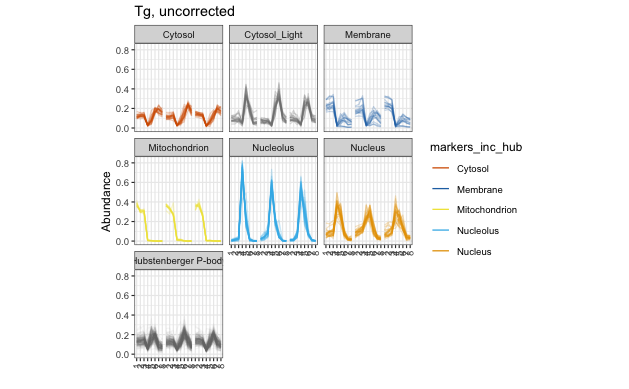

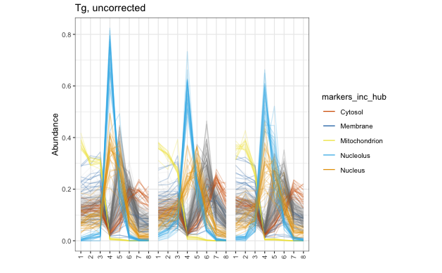

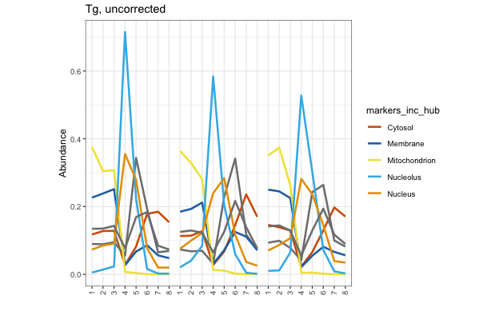

[4 more figures not shown]

```r
for(condition in names(dlorna$gene)){
  for(correction in names(dlorna$gene[[condition]])){
  .data <- dlorna$gene[[condition]][[correction]]

    title <- paste(condition, correction, sep=', ')

    fData(.data)$markers_inc_hub <- fData(.data)$markers
    fData(.data)$markers_inc_hub[
      ((getMarkers(.data, 'markers')=='unknown') &
         (rownames(.data) %in% Hubstenberger_et_al_enr$ensembl_gene_id))] <- 'Hubstenberger P-body'
    fData(.data)$markers_inc_hub <- factor(fData(.data)$markers_inc_hub,
                                           levels=c(getMarkerClasses(.data, 'markers'),
                                                    c('Hubstenberger P-body', 'unknown')))

    .pca <- plot2D(.data, fcol='markers_inc_hub', col=c(colours, 'black'), main=title)
    addLegend(.data, where='bottomleft', fcol='markers_inc_hub', col=c(colours, 'black'))

    p <- plot_marker_profiles(.data[fData(.data)$markers_inc_hub!='unknown',], 'markers_inc_hub',
                         group_by='replicate', alpha=c(rep(0.25, 6), 0.05), facet_by='markers') +
      scale_colour_manual(values=c(colours, 'black')) +
      scale_x_discrete(labels=pData(.data)$fraction) +
      ggtitle(title)


    p2 <- plot_marker_profiles(.data[fData(.data)$markers_inc_hub!='unknown',], 'markers_inc_hub',
                         group_by='replicate', alpha=c(rep(0.25, 6), 0.05)) +
      scale_colour_manual(values=c(colours, 'black')) +
      scale_x_discrete(labels=pData(.data)$fraction) +
      ggtitle(title)

    p3 <- plot_marker_profiles(.data[fData(.data)$markers_inc_hub!='unknown',], 'markers_inc_hub',
                         group_by='replicate', plot_all=FALSE) +
      scale_colour_manual(values=c(colours, 'black')) +
      scale_x_discrete(labels=pData(.data)$fraction) +
      ggtitle(title)

    print(p)
    print(p2)
    print(p3)
  }

}
```

Comparison with Khong et al: https://pubmed.ncbi.nlm.nih.gov/29129640/

```r
khong_et_al <- readxl::read_excel('../../../../../1_external/3_granules/Khong_et_al_2017/1-s2.0-S1097276517307906-mmc2.xlsx', sheet=1)

p <- mean_proportions_to_plot$gene %>% filter(condition=='Tg', localisation=='Cytosol_Light') %>%
  merge(khong_et_al, by.x='id', by.y='test_id') %>%
  mutate(Localization=factor(Localization, levels=c('enriched', 'Neither', 'depleted'))) %>%
  ggplot(aes(proportion, x=log2(`Fold change`))) +
  geom_point(aes(colour=Localization, alpha=Localization), size=0.5, alpha=0.1) +
  geom_smooth() +
  theme_camprot(border=FALSE, base_family='sans') +
  xlim(-5, NA) +
  scale_colour_manual(values=c(get_cat_palette(1), 'grey', get_cat_palette(2)[2]), name='Khong et al (2017)',
                      labels=c('Enriched', 'Neither', 'Depleted')) +
  scale_alpha_manual(values=c(1, 0.1, 1), name='Khong et al',
                      labels=c('Enriched', 'Neither', 'Depleted')) +
  guides(color = guide_legend(override.aes = list(alpha = 1, size=3))) +
  ylab('LoRNA cytosol light\nproportion (UPR)') +
  xlab('Khong et al (2017)\nSG/Total (log2)') +
  ylim(0,1)

print(p)

ggsave('../../../../../5_manuscript_figures/Figure_5/external/Khong.png', width=4, height=4)
```

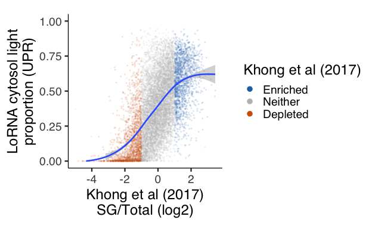

```r
ggsave('../../../../../5_manuscript_figures/Figure_5/external/Khong.pdf', width=4, height=4)
```

Any relationship between relocalisation to membrane and change in RNA abundance?

```r
RNA_abundance_change <- readRDS('../../1_Differential_abundance/results/DESeq2_results.rds')
```

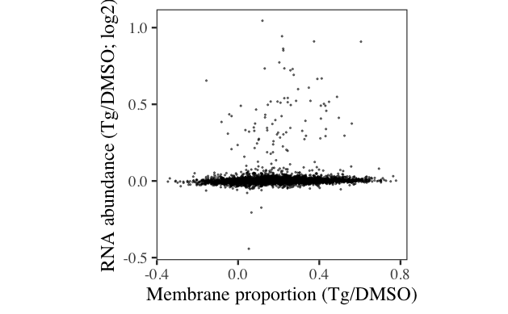

```r
proportions$gene %>%
  dplyr::select(id, condition, loi=Cytosol_Light) %>%
  pivot_wider(names_from=condition, id_cols=id, values_from=loi) %>%
  filter(is.finite(DMSO), is.finite(Tg)) %>%
  mutate(change=Tg-DMSO) %>%
  merge(RNA_abundance_change, by.y='row.names', by.x='id') %>%
  filter(Tg>0.5) %>%
  ggplot(aes(change, log2FoldChange)) +
  geom_point(alpha=0.5, size=0.5) +
  theme_camprot() +
  xlab('Membrane proportion (Tg/DMSO)') +
  ylab('RNA abundance (Tg/DMSO; log2)')
```

```r
x <- proportions$gene %>%
  merge(RNA_abundance_change, by.y='row.names', by.x='id') %>%
  filter(padj<0.05, log2FoldChange<0) %>%
  arrange(log2FoldChange)

print(x %>% filter(x$id %in% x$id[duplicated(x$id)]))
```

| id | condition | sd_Cytosol | sd_Cytosol_Light | sd_Nucleus | sd_Nucleolus | sd_Membrane | Cytosol | Cytosol_Light | Nucleus | Nucleolus | Membrane | baseMean | log2FoldChange | lfcSE | pvalue | padj |
| --- | --- | --- | --- | --- | --- | --- | --- | --- | --- | --- | --- | --- | --- | --- | --- | --- |
| ENSG00000151474 | DMSO | 0.27181676 | 0.002620916 | 0.27006683 | 0.058686680 | 0.0630575224 | 0.70377700 | 0.00833850 | 0.1909661 | 0.05233002 | 0.0445884017 | 1088.7029 | -0.7447139 | 0.1834012 | 1.960983e-06 | 0.0006349965 |
| ENSG00000151474 | Tg | 0.28436956 | 0.076091202 | 0.19141680 | 0.002767564 | 0.0140939991 | 0.78883575 | 0.05380460 | 0.1353521 | 0.01204156 | 0.0099659623 | 1088.7029 | -0.7447139 | 0.1834012 | 1.960983e-06 | 0.0006349965 |
| ENSG00000215417 | DMSO | 0.02070153 | 0.005871379 | 0.07226594 | 0.059946012 | 0.0000000000 | 0.01337725 | 0.03561707 | 0.8689124 | 0.08209324 | 0.0000000000 | 900.9201 | -0.6304055 | 0.2316198 | 2.177157e-04 | 0.0322709863 |
| ENSG00000215417 | Tg | 0.01385676 | 0.143336938 | 0.21484365 | 0.100666805 | 0.0009172752 | 0.01032030 | 0.34918731 | 0.3923524 | 0.24718778 | 0.0009521831 | 900.9201 | -0.6304055 | 0.2316198 | 2.177157e-04 | 0.0322709863 |

Comparison with Horste et al

```r
Horste_el_al_2022 <- readxl::read_excel('../../../../../1_external/3_granules/Horste_el_al_2022/Table_S1_final.xlsx', range='A1:V9156',
                                        col_types=c(rep('guess', 8), 'text', 'text', rep('guess', 12))) %>%
  mutate(classification=ifelse(!is.na(`TMD classification`), `TMD classification`, `Non-TMD_classification`))
```

```r
colnames(Horste_el_al_2022)
```

```
 [1] "Gene_name"                      "Refseq_ID"                      "HEK293T_expressed"              "NonTMD[3]_TMD[2]_SEC[1]"        "Protein_size"
 [6] "3'UTR_length"                   "AUUUA_3'UTR"                    "AU_3'UTR"                       "TMD classification"             "Non-TMD_classification"
[11] "avProtein_abund_x10^7"          "av_WCL[RPKM]"                   "avCyto[RPKM]"                   "avTG[RPKM]"                     "[RPKM]"
[16] "SUM_cytoplasm[RPKM]"            "Partition coefficient (Pco)_TG" "Pco_ER"                         "Pco_CY"                         "Compartment enrichment_TG"
[21] "Compartment enrichment_ER"      "Compartment enrichment_CY"      "classification"
```

```r
table(Horste_el_al_2022$`classification`, (Horste_el_al_2022$`Partition coefficient (Pco)_TG`/Horste_el_al_2022$`Pco_ER`)>1/0.8)
```

```
       FALSE TRUE
  CRER  2395    0
  CY    1463  244
  NL    2810  785
  TGER   107 1351
```

```r
table(Horste_el_al_2022$`TMD classification`)
```

```
CRER   CY   NL TGER
1476  226  226  212
```

```r
table(Horste_el_al_2022$`TMD classification`, (Horste_el_al_2022$`Partition coefficient (Pco)_TG`/Horste_el_al_2022$`Pco_ER`)>1/0.8)
```

```
       FALSE TRUE
  CRER  1476    0
  CY     185   41
  NL     225    1
  TGER    46  166
```

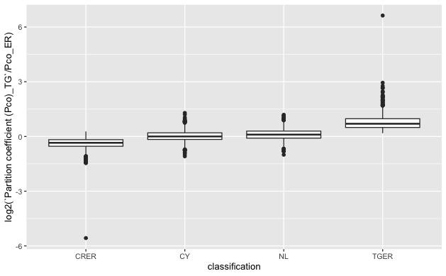

```r
ggplot(Horste_el_al_2022, aes(`classification`, log2(`Partition coefficient (Pco)_TG`/`Pco_ER`))) +
  geom_boxplot()
```

```r
ensembl <- useEnsembl(biomart="ensembl", version=102, dataset="hsapiens_gene_ensembl")

listAttributes(ensembl)
```

[output not shown]

[output cut: 990 more lines]

```r
gene_id_name <- getBM(attributes=c('ensembl_gene_id',
                                         'external_gene_name'),
                                         mart = ensembl,
                     filters = 'external_gene_name',
                     values=unique(Horste_el_al_2022$Gene_name))
```

```
Batch submitting query [=============================================================>---------------------------------------------------------------]  50% eta:  1s
```

```r
Horste_el_al_2022<- Horste_el_al_2022 %>%
  merge(gene_id_name, by.x='Gene_name', by.y='external_gene_name')
```

[output not shown]

[output cut: 2 more lines]

```r
library(ggtern)
```

```r
for(class in setdiff(unique(Horste_el_al_2022$classification), 'NL')){
  p <- proportions$gene %>%
  filter(condition=='DMSO') %>%
  mutate('Nucleus'=Nucleus+Nucleolus) %>%
  dplyr::select(id, 'Granule'=Cytosol_Light, Cytosol, Nucleus, Membrane)  %>%
  merge(Horste_el_al_2022[,c('ensembl_gene_id', 'classification')], by.x='id', by.y='ensembl_gene_id') %>%
  filter(classification==class) %>%
      ggtern(aes(x=Cytosol, y=Membrane, z=Granule)) +
  geom_point(size=0.25, alpha=0.5) +
      theme_bw(base_size=15) +
      theme_arrowlarge() +
      theme_hideticks() +
      theme_hidetitles() +
      xlab('Cytosol') +
      ylab('Membrane') +
      zlab('Granule') +
      theme(strip.background = element_blank(),
            strip.text.x=element_text(size=15, vjust=2),
            strip.text.y=element_text(size=15, vjust=2)) +
    ggtitle(class)

  print(p)
}

proportions$gene %>%
  filter(condition=='DMSO') %>%
  mutate('Nucleus'=Nucleus+Nucleolus) %>%
  dplyr::select(id, 'Granule'=Cytosol_Light, Cytosol, Nucleus, Membrane)  %>%
  merge(Horste_el_al_2022[,c('ensembl_gene_id', 'classification')], by.x='id', by.y='ensembl_gene_id') %>%
  filter(classification!='NL') %>%
      ggtern(aes(x=Cytosol, y=Membrane, z=Granule, colour=classification)) +
  geom_point(size=0.25, alpha=0.5) +
      theme_bw(base_size=15) +
      theme_arrowlarge() +
      theme_hideticks() +
      theme_hidetitles() +
      xlab('Cytosol') +
      ylab('Membrane') +
      zlab('Granule') +
      theme(strip.background = element_blank(),
            strip.text.x=element_text(size=15, vjust=2),
            strip.text.y=element_text(size=15, vjust=2))

p <- proportions$gene %>%
  filter(condition=='DMSO') %>%
  mutate('Nucleus'=Nucleus+Nucleolus) %>%
  dplyr::select(id, 'Granule'=Cytosol_Light, Cytosol, Nucleus, Membrane)  %>%
  filter(id %in% Hubstenberger_et_al_enr$ensembl_gene_id) %>%
      ggtern(aes(x=Cytosol, y=Membrane, z=Granule)) +
  geom_point(size=0.25, alpha=0.5) +
      theme_bw(base_size=15) +
      theme_arrowlarge() +
      theme_hideticks() +
      theme_hidetitles() +
      xlab('Cytosol') +
      ylab('Membrane') +
      zlab('Granule') +
      theme(strip.background = element_blank(),
            strip.text.x=element_text(size=15, vjust=2),
            strip.text.y=element_text(size=15, vjust=2)) +
    ggtitle('Hubstenberger et al')

print(p)
```

[output not shown]